# Risk Factor Analysis

## Outcome Variable

**Outcome Variable:** dead0plus

## Predictor Variables

**Intervention Variable:** ever_stunted024

**Adjustment Set:**

- sex
- arm
- brthmon
- vagbrth
- hhwealth_quart
- W_mage
- W_mhtcm
- W_mwtkg
- W_mbmi
- W_meducyrs
- W_feducyrs
- W_nrooms
- W_parity
- impsan
- safeh20
- delta_vagbrth
- delta_hhwealth_quart
- delta_W_mage
- delta_W_mhtcm
- delta_W_mwtkg
- delta_W_mbmi
- delta_W_meducyrs
- delta_W_feducyrs
- delta_W_nrooms
- delta_W_parity
- delta_impsan
- delta_safeh20

## Stratifying Variables

The analysis was stratified on these variable(s):

- studyid
- country

## Data Summary

| studyid | country | ever_stunted024 | dead0plus | n_cell | n | outcome_variable |
| --- | --- | --- | --- | --- | --- | --- |
| Burkina Faso Zn | BURKINA FASO | 0 | 0 | 4565 | 7164 | dead0plus |
| Burkina Faso Zn | BURKINA FASO | 0 | 1 | 25 | 7164 | dead0plus |
| Burkina Faso Zn | BURKINA FASO | 1 | 0 | 2551 | 7164 | dead0plus |
| Burkina Faso Zn | BURKINA FASO | 1 | 1 | 23 | 7164 | dead0plus |
| EE | PAKISTAN | 0 | 0 | 41 | 379 | dead0plus |
| EE | PAKISTAN | 0 | 1 | 0 | 379 | dead0plus |
| EE | PAKISTAN | 1 | 0 | 334 | 379 | dead0plus |
| EE | PAKISTAN | 1 | 1 | 4 | 379 | dead0plus |
| GMS-Nepal | NEPAL | 0 | 0 | 249 | 698 | dead0plus |
| GMS-Nepal | NEPAL | 0 | 1 | 3 | 698 | dead0plus |
| GMS-Nepal | NEPAL | 1 | 0 | 441 | 698 | dead0plus |
| GMS-Nepal | NEPAL | 1 | 1 | 5 | 698 | dead0plus |
| iLiNS-DOSE | MALAWI | 0 | 0 | 902 | 1931 | dead0plus |
| iLiNS-DOSE | MALAWI | 0 | 1 | 62 | 1931 | dead0plus |
| iLiNS-DOSE | MALAWI | 1 | 0 | 901 | 1931 | dead0plus |
| iLiNS-DOSE | MALAWI | 1 | 1 | 66 | 1931 | dead0plus |
| iLiNS-DYAD-M | MALAWI | 0 | 0 | 612 | 1204 | dead0plus |
| iLiNS-DYAD-M | MALAWI | 0 | 1 | 20 | 1204 | dead0plus |
| iLiNS-DYAD-M | MALAWI | 1 | 0 | 549 | 1204 | dead0plus |
| iLiNS-DYAD-M | MALAWI | 1 | 1 | 23 | 1204 | dead0plus |
| JiVitA-3 | BANGLADESH | 0 | 0 | 13473 | 27227 | dead0plus |
| JiVitA-3 | BANGLADESH | 0 | 1 | 268 | 27227 | dead0plus |
| JiVitA-3 | BANGLADESH | 1 | 0 | 12911 | 27227 | dead0plus |
| JiVitA-3 | BANGLADESH | 1 | 1 | 575 | 27227 | dead0plus |
| JiVitA-4 | BANGLADESH | 0 | 0 | 2264 | 5442 | dead0plus |
| JiVitA-4 | BANGLADESH | 0 | 1 | 15 | 5442 | dead0plus |
| JiVitA-4 | BANGLADESH | 1 | 0 | 3128 | 5442 | dead0plus |
| JiVitA-4 | BANGLADESH | 1 | 1 | 35 | 5442 | dead0plus |
| Keneba | GAMBIA | 0 | 0 | 1384 | 2915 | dead0plus |
| Keneba | GAMBIA | 0 | 1 | 37 | 2915 | dead0plus |
| Keneba | GAMBIA | 1 | 0 | 1432 | 2915 | dead0plus |
| Keneba | GAMBIA | 1 | 1 | 62 | 2915 | dead0plus |
| MAL-ED | BANGLADESH | 0 | 0 | 103 | 265 | dead0plus |
| MAL-ED | BANGLADESH | 0 | 1 | 0 | 265 | dead0plus |
| MAL-ED | BANGLADESH | 1 | 0 | 159 | 265 | dead0plus |
| MAL-ED | BANGLADESH | 1 | 1 | 3 | 265 | dead0plus |
| MAL-ED | INDIA | 0 | 0 | 98 | 251 | dead0plus |
| MAL-ED | INDIA | 0 | 1 | 1 | 251 | dead0plus |
| MAL-ED | INDIA | 1 | 0 | 151 | 251 | dead0plus |
| MAL-ED | INDIA | 1 | 1 | 1 | 251 | dead0plus |
| MAL-ED | PERU | 0 | 0 | 114 | 303 | dead0plus |
| MAL-ED | PERU | 0 | 1 | 1 | 303 | dead0plus |
| MAL-ED | PERU | 1 | 0 | 187 | 303 | dead0plus |
| MAL-ED | PERU | 1 | 1 | 1 | 303 | dead0plus |
| MAL-ED | SOUTH AFRICA | 0 | 0 | 138 | 314 | dead0plus |
| MAL-ED | SOUTH AFRICA | 0 | 1 | 0 | 314 | dead0plus |
| MAL-ED | SOUTH AFRICA | 1 | 0 | 175 | 314 | dead0plus |
| MAL-ED | SOUTH AFRICA | 1 | 1 | 1 | 314 | dead0plus |
| MAL-ED | TANZANIA, UNITED REPUBLIC OF | 0 | 0 | 39 | 262 | dead0plus |
| MAL-ED | TANZANIA, UNITED REPUBLIC OF | 0 | 1 | 1 | 262 | dead0plus |
| MAL-ED | TANZANIA, UNITED REPUBLIC OF | 1 | 0 | 220 | 262 | dead0plus |
| MAL-ED | TANZANIA, UNITED REPUBLIC OF | 1 | 1 | 2 | 262 | dead0plus |
| PROVIDE | BANGLADESH | 0 | 0 | 391 | 700 | dead0plus |
| PROVIDE | BANGLADESH | 0 | 1 | 4 | 700 | dead0plus |
| PROVIDE | BANGLADESH | 1 | 0 | 304 | 700 | dead0plus |
| PROVIDE | BANGLADESH | 1 | 1 | 1 | 700 | dead0plus |
| SAS-CompFeed | INDIA | 0 | 0 | 461 | 1533 | dead0plus |
| SAS-CompFeed | INDIA | 0 | 1 | 12 | 1533 | dead0plus |
| SAS-CompFeed | INDIA | 1 | 0 | 1022 | 1533 | dead0plus |
| SAS-CompFeed | INDIA | 1 | 1 | 38 | 1533 | dead0plus |
| SAS-FoodSuppl | INDIA | 0 | 0 | 71 | 418 | dead0plus |
| SAS-FoodSuppl | INDIA | 0 | 1 | 1 | 418 | dead0plus |
| SAS-FoodSuppl | INDIA | 1 | 0 | 341 | 418 | dead0plus |
| SAS-FoodSuppl | INDIA | 1 | 1 | 5 | 418 | dead0plus |
| TanzaniaChild2 | TANZANIA, UNITED REPUBLIC OF | 0 | 0 | 1566 | 2396 | dead0plus |
| TanzaniaChild2 | TANZANIA, UNITED REPUBLIC OF | 0 | 1 | 1 | 2396 | dead0plus |
| TanzaniaChild2 | TANZANIA, UNITED REPUBLIC OF | 1 | 0 | 829 | 2396 | dead0plus |
| TanzaniaChild2 | TANZANIA, UNITED REPUBLIC OF | 1 | 1 | 0 | 2396 | dead0plus |
| VITAMIN-A | INDIA | 0 | 0 | 1665 | 3907 | dead0plus |
| VITAMIN-A | INDIA | 0 | 1 | 27 | 3907 | dead0plus |
| VITAMIN-A | INDIA | 1 | 0 | 2165 | 3907 | dead0plus |
| VITAMIN-A | INDIA | 1 | 1 | 50 | 3907 | dead0plus |
| ZVITAMBO | ZIMBABWE | 0 | 0 | 7637 | 14074 | dead0plus |
| ZVITAMBO | ZIMBABWE | 0 | 1 | 566 | 14074 | dead0plus |
| ZVITAMBO | ZIMBABWE | 1 | 0 | 5321 | 14074 | dead0plus |
| ZVITAMBO | ZIMBABWE | 1 | 1 | 550 | 14074 | dead0plus |

The following strata were considered:

- studyid: Burkina Faso Zn, country: BURKINA FASO
- studyid: EE, country: PAKISTAN
- studyid: GMS-Nepal, country: NEPAL
- studyid: iLiNS-DOSE, country: MALAWI
- studyid: iLiNS-DYAD-M, country: MALAWI
- studyid: JiVitA-3, country: BANGLADESH
- studyid: JiVitA-4, country: BANGLADESH
- studyid: Keneba, country: GAMBIA
- studyid: MAL-ED, country: BANGLADESH
- studyid: MAL-ED, country: INDIA
- studyid: MAL-ED, country: PERU
- studyid: MAL-ED, country: SOUTH AFRICA
- studyid: MAL-ED, country: TANZANIA, UNITED REPUBLIC OF
- studyid: PROVIDE, country: BANGLADESH
- studyid: SAS-CompFeed, country: INDIA
- studyid: SAS-FoodSuppl, country: INDIA
- studyid: TanzaniaChild2, country: TANZANIA, UNITED REPUBLIC OF
- studyid: VITAMIN-A, country: INDIA
- studyid: ZVITAMBO, country: ZIMBABWE

### Dropped Strata

Some strata were dropped due to rare outcomes:

- studyid: EE, country: PAKISTAN
- studyid: GMS-Nepal, country: NEPAL
- studyid: MAL-ED, country: BANGLADESH
- studyid: MAL-ED, country: INDIA
- studyid: MAL-ED, country: PERU
- studyid: MAL-ED, country: SOUTH AFRICA
- studyid: MAL-ED, country: TANZANIA, UNITED REPUBLIC OF
- studyid: PROVIDE, country: BANGLADESH
- studyid: SAS-FoodSuppl, country: INDIA
- studyid: TanzaniaChild2, country: TANZANIA, UNITED REPUBLIC OF

## Methods Detail

We’re interested in the causal parameters $E[Y_a]$ for all values of $a \in \mathcal{A}$. These parameters represent the mean outcome if, possibly contrary to fact, we intervened to set all units to have $A=a$. Under the randomization and positivity assumptions, these are identified by the statistical parameters $\psi_a=E_W[E_{Y|A,W}(Y|A=a,W)]$. In addition, we’re interested in the mean of $Y$, $E[Y]$ under no intervention (the observed mean). We will estimate these parameters by using SuperLearner to fit the relevant likelihood factors – $E_{Y|A,W}(Y|A=a,W)$ and $p(A=a|W)$, and then updating our likelihood fit using a joint TMLE.

For unadjusted analyses ($W=\{\}$), initial likelihoods were estimated using Lrnr_glm to estimate the simple $E(Y|A)$ and Lrnr_mean to estimate $p(A)$. For adjusted analyses, a small library containing Lrnr_glmnet, Lrnr_xgboost, and Lrnr_mean was used.

Having estimated these parameters, we will then use the delta method to estimate relative risks and attributable risks relative to a prespecified baseline level of $A$.

# Results Detail

## Results Plots

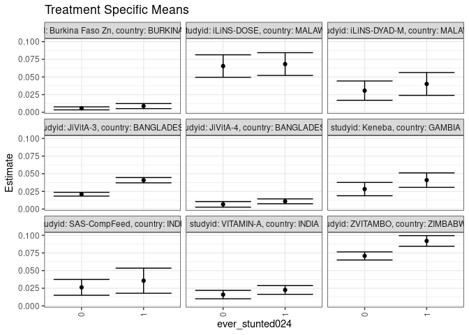

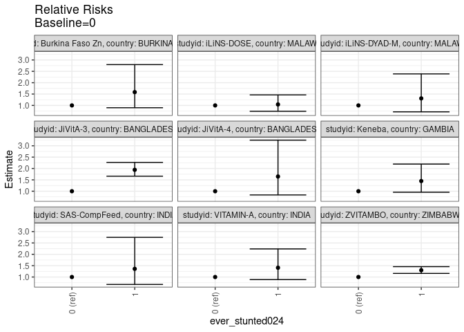

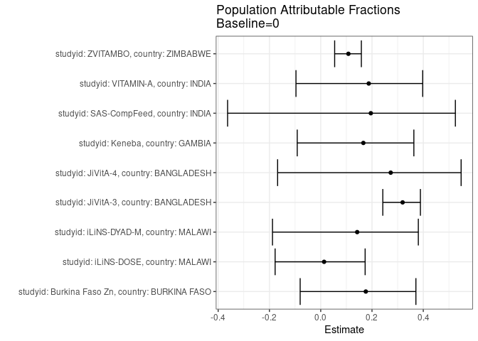

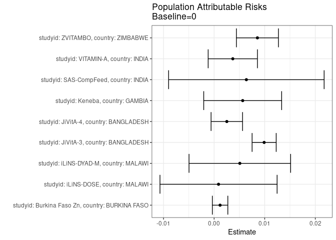

## Results Table

### Parameter: TSM

| studyid | country | intervention_level | baseline_level | estimate | ci_lower | ci_upper |
| --- | --- | --- | --- | --- | --- | --- |
| Burkina Faso Zn | BURKINA FASO | 0 | NA | 0.0055219 | 0.0033637 | 0.0076800 |
| Burkina Faso Zn | BURKINA FASO | 1 | NA | 0.0087546 | 0.0051490 | 0.0123602 |
| iLiNS-DOSE | MALAWI | 0 | NA | 0.0654125 | 0.0494766 | 0.0813485 |
| iLiNS-DOSE | MALAWI | 1 | NA | 0.0682242 | 0.0521181 | 0.0843303 |
| iLiNS-DYAD-M | MALAWI | 0 | NA | 0.0306345 | 0.0169778 | 0.0442913 |
| iLiNS-DYAD-M | MALAWI | 1 | NA | 0.0401041 | 0.0239431 | 0.0562652 |
| JiVitA-3 | BANGLADESH | 0 | NA | 0.0210719 | 0.0184045 | 0.0237393 |
| JiVitA-3 | BANGLADESH | 1 | NA | 0.0409052 | 0.0371721 | 0.0446383 |
| JiVitA-4 | BANGLADESH | 0 | NA | 0.0066789 | 0.0026967 | 0.0106612 |
| JiVitA-4 | BANGLADESH | 1 | NA | 0.0110055 | 0.0075516 | 0.0144595 |
| Keneba | GAMBIA | 0 | NA | 0.0283145 | 0.0188856 | 0.0377434 |
| Keneba | GAMBIA | 1 | NA | 0.0410014 | 0.0307836 | 0.0512192 |
| SAS-CompFeed | INDIA | 0 | NA | 0.0262402 | 0.0150429 | 0.0374375 |
| SAS-CompFeed | INDIA | 1 | NA | 0.0356867 | 0.0179198 | 0.0534537 |
| VITAMIN-A | INDIA | 0 | NA | 0.0160154 | 0.0100557 | 0.0219751 |
| VITAMIN-A | INDIA | 1 | NA | 0.0225710 | 0.0163854 | 0.0287567 |
| ZVITAMBO | ZIMBABWE | 0 | NA | 0.0707356 | 0.0649912 | 0.0764800 |
| ZVITAMBO | ZIMBABWE | 1 | NA | 0.0919382 | 0.0844123 | 0.0994641 |

### Parameter: E(Y)

| studyid | country | intervention_level | baseline_level | estimate | ci_lower | ci_upper |
| --- | --- | --- | --- | --- | --- | --- |
| Burkina Faso Zn | BURKINA FASO | NA | NA | 0.0067002 | 0.0048109 | 0.0085894 |
| iLiNS-DOSE | MALAWI | NA | NA | 0.0662869 | 0.0551877 | 0.0773861 |
| iLiNS-DYAD-M | MALAWI | NA | NA | 0.0357143 | 0.0252276 | 0.0462010 |
| JiVitA-3 | BANGLADESH | NA | NA | 0.0309619 | 0.0288229 | 0.0331009 |
| JiVitA-4 | BANGLADESH | NA | NA | 0.0091878 | 0.0066008 | 0.0117748 |
| Keneba | GAMBIA | NA | NA | 0.0339623 | 0.0273857 | 0.0405388 |
| SAS-CompFeed | INDIA | NA | NA | 0.0326158 | 0.0204960 | 0.0447355 |
| VITAMIN-A | INDIA | NA | NA | 0.0197082 | 0.0153493 | 0.0240672 |
| ZVITAMBO | ZIMBABWE | NA | NA | 0.0792952 | 0.0748310 | 0.0837593 |

### Parameter: RR

| studyid | country | intervention_level | baseline_level | estimate | ci_lower | ci_upper |
| --- | --- | --- | --- | --- | --- | --- |
| Burkina Faso Zn | BURKINA FASO | 0 | 0 | 1.000000 | 1.0000000 | 1.000000 |
| Burkina Faso Zn | BURKINA FASO | 1 | 0 | 1.585438 | 0.8984956 | 2.797582 |
| iLiNS-DOSE | MALAWI | 0 | 0 | 1.000000 | 1.0000000 | 1.000000 |
| iLiNS-DOSE | MALAWI | 1 | 0 | 1.042983 | 0.7428941 | 1.464291 |
| iLiNS-DYAD-M | MALAWI | 0 | 0 | 1.000000 | 1.0000000 | 1.000000 |
| iLiNS-DYAD-M | MALAWI | 1 | 0 | 1.309116 | 0.7178846 | 2.387271 |
| JiVitA-3 | BANGLADESH | 0 | 0 | 1.000000 | 1.0000000 | 1.000000 |
| JiVitA-3 | BANGLADESH | 1 | 0 | 1.941220 | 1.6619850 | 2.267371 |
| JiVitA-4 | BANGLADESH | 0 | 0 | 1.000000 | 1.0000000 | 1.000000 |
| JiVitA-4 | BANGLADESH | 1 | 0 | 1.647796 | 0.8358533 | 3.248455 |
| Keneba | GAMBIA | 0 | 0 | 1.000000 | 1.0000000 | 1.000000 |
| Keneba | GAMBIA | 1 | 0 | 1.448069 | 0.9551632 | 2.195336 |
| SAS-CompFeed | INDIA | 0 | 0 | 1.000000 | 1.0000000 | 1.000000 |
| SAS-CompFeed | INDIA | 1 | 0 | 1.360002 | 0.6736292 | 2.745734 |
| VITAMIN-A | INDIA | 0 | 0 | 1.000000 | 1.0000000 | 1.000000 |
| VITAMIN-A | INDIA | 1 | 0 | 1.409334 | 0.8877853 | 2.237277 |
| ZVITAMBO | ZIMBABWE | 0 | 0 | 1.000000 | 1.0000000 | 1.000000 |
| ZVITAMBO | ZIMBABWE | 1 | 0 | 1.299745 | 1.1592212 | 1.457305 |

### Parameter: PAR

| studyid | country | intervention_level | baseline_level | estimate | ci_lower | ci_upper |
| --- | --- | --- | --- | --- | --- | --- |
| Burkina Faso Zn | BURKINA FASO | 0 | NA | 0.0011783 | -0.0003519 | 0.0027085 |
| iLiNS-DOSE | MALAWI | 0 | NA | 0.0008743 | -0.0107022 | 0.0124509 |
| iLiNS-DYAD-M | MALAWI | 0 | NA | 0.0050798 | -0.0049609 | 0.0151205 |
| JiVitA-3 | BANGLADESH | 0 | NA | 0.0098900 | 0.0075086 | 0.0122714 |
| JiVitA-4 | BANGLADESH | 0 | NA | 0.0025089 | -0.0006017 | 0.0056194 |
| Keneba | GAMBIA | 0 | NA | 0.0056477 | -0.0020537 | 0.0133491 |
| SAS-CompFeed | INDIA | 0 | NA | 0.0063756 | -0.0089958 | 0.0217469 |
| VITAMIN-A | INDIA | 0 | NA | 0.0036928 | -0.0011756 | 0.0085613 |
| ZVITAMBO | ZIMBABWE | 0 | NA | 0.0085596 | 0.0044066 | 0.0127126 |

### Parameter: PAF

| studyid | country | intervention_level | baseline_level | estimate | ci_lower | ci_upper |
| --- | --- | --- | --- | --- | --- | --- |
| Burkina Faso Zn | BURKINA FASO | 0 | NA | 0.1758622 | -0.0801713 | 0.3712080 |
| iLiNS-DOSE | MALAWI | 0 | NA | 0.0131904 | -0.1778437 | 0.1732407 |
| iLiNS-DYAD-M | MALAWI | 0 | NA | 0.1422335 | -0.1880708 | 0.3807075 |
| JiVitA-3 | BANGLADESH | 0 | NA | 0.3194248 | 0.2421353 | 0.3888321 |
| JiVitA-4 | BANGLADESH | 0 | NA | 0.2730639 | -0.1681098 | 0.5476144 |
| Keneba | GAMBIA | 0 | NA | 0.1662944 | -0.0915987 | 0.3632596 |
| SAS-CompFeed | INDIA | 0 | NA | 0.1954752 | -0.3632458 | 0.5252065 |
| VITAMIN-A | INDIA | 0 | NA | 0.1873748 | -0.0964903 | 0.3977514 |
| ZVITAMBO | ZIMBABWE | 0 | NA | 0.1079460 | 0.0543570 | 0.1584982 |